# 03. Aesthetics and Scales

## Additional Aesthetics

In the introduction to the grammar of graphics, we saw that visualizations can be built out of graphics layers. Each layer, in turn, is described by a dataset, a geometry, and a series of aes (aesthetic) mappings between variables and features of the layer. The point and line geometries require `x` and `y` aesthetics; the text and text repel layers also required a `label` aesthetic.

In addition to the required aesthetics, each geometry type also has a number of optional aesthetics that we can use to add additional information to the plot. For example, most geoms have a `color` aesthetic. The syntax for describing this is exactly the same as with the required aesthetics; we place the name of the aesthetic followed by the name of the associated variable name. Let’s see what happens when add a color aesthetic this to our scatterplot by relating the varible `food_group` to the aes `color`:

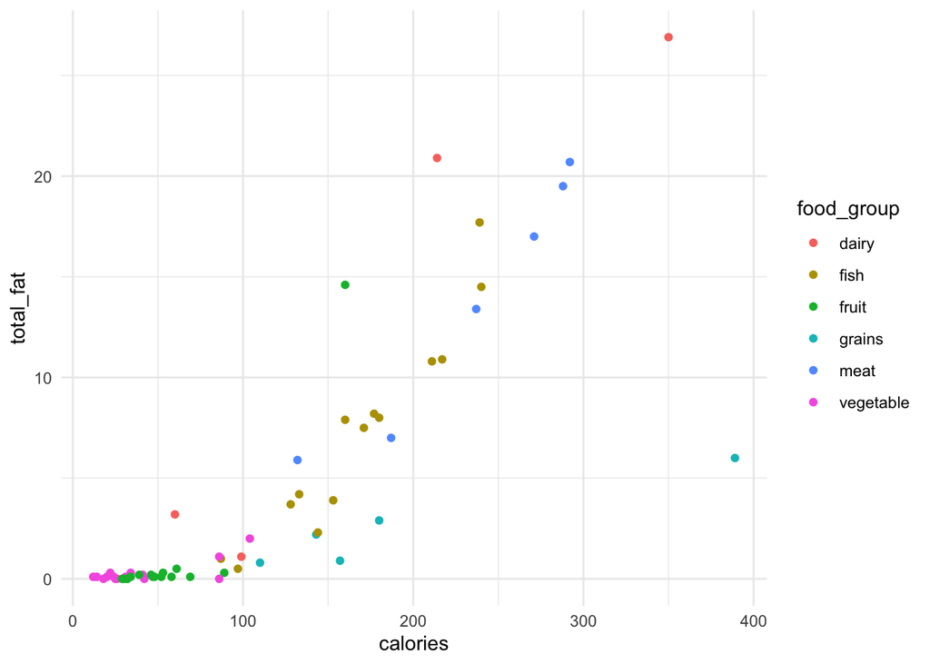

```r
food %>%
  ggplot() +
    geom_point(aes(x = calories, y = total_fat, color = food_group))
```

Notice that R has done a lot of work for us. It determined all of the food groups in the dataset, assigned each to a color, built a legend, and modified the points on the plot so that the colors align with the food groups. Can you now tell what types of food have a large number of calories and fat? Which kinds of food have the lowest calories and fat? What is the biggest difference between fruits and vegetables from the plot?

Similarly, we can modify the size of the points according to a variable in the dataset by setting the `size` aesthetic. Here, we will make points larger or smaller based on the saturated fat in each food item:

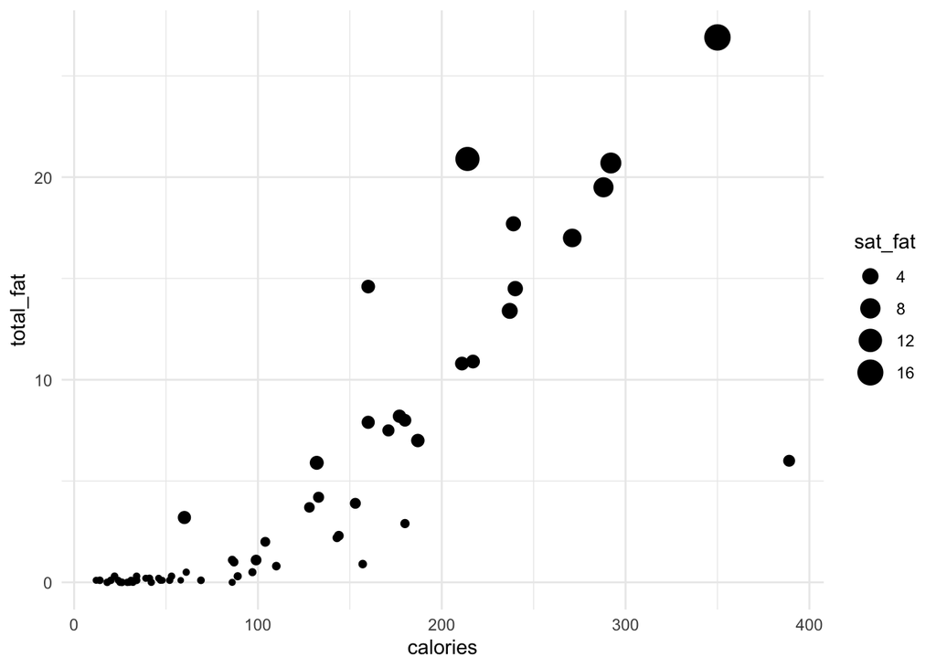

```r
food %>%
  ggplot() +
    geom_point(aes(x = calories, y = total_fat, size = sat_fat))
```

Both size and color can also be specified for the text, text repel, and line geometries. There are a few other aesthetics that will be useful, and that we will introduce as needed. At the end of this chapter is a reference where you can find all of the aesthetic types associated with each geom.

## Fixed Aesthetics

In the previous section we changed the default aes value for the color and size of points by associating these to a variable in the dataset. In the plots from the last chapter, where we did not specify color or size, R choose a default value for these: the color “black” and the size 1. What if we want to change the defaults to a different fixed value? This can be done relatively easily, but take care with the details because this is a common source of confusing errors for users new to the geometry of graphics.

To change an aes to a fixed value, we specify the changed value inside the `geom_` function, but **after** the `aes(` function. Here, for example, is how we change the size of all the points to 4 (four times larger than the default):

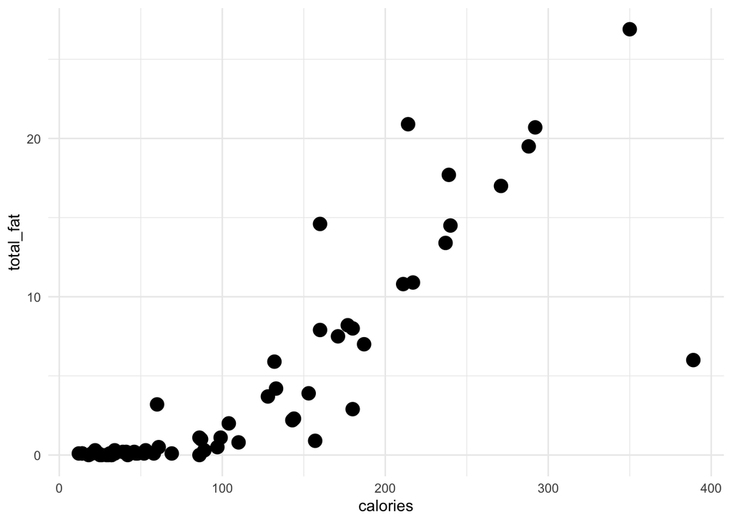

```r
food %>%
  ggplot() +
    geom_point(aes(x = calories, y = total_fat), size = 4)
```

We can do the same with colors, but notice that we need to put the color name inside of quotes:

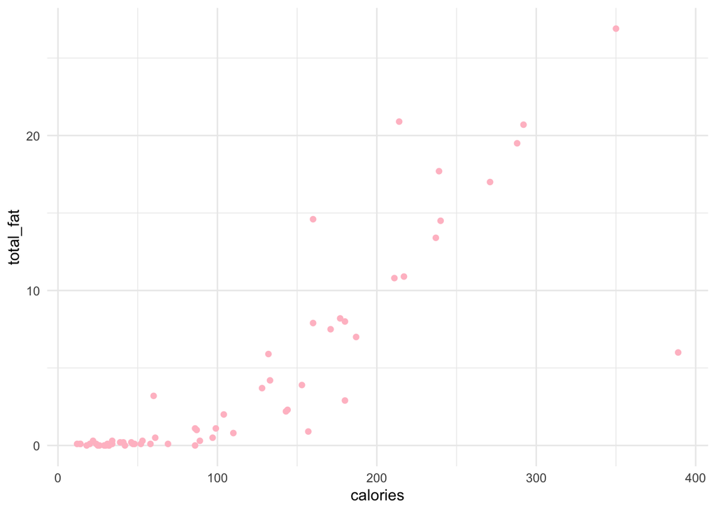

```r
food %>%
  ggplot() +
    geom_point(aes(x = calories, y = total_fat), color = "pink")
```

For a list of available color names, see [this file](http://www.stat.columbia.edu/~tzheng/files/Rcolor.pdf). You can interchange the fixed and variable aes commands, and the relative order should not effect the output. Just be sure the put fixed terms after closing the aes command.

## Scales

In the examples above, R handles the specifics of how to pick the specific colors and sizes. R has also figured how how large to make the axes, where to add tick marks, and where to draw grid lines. Letting R deal with these details is convenient because it frees us up to focus on the data itself. Sometimes, such as when preparing to produce plots for external distribution, it is useful to manually adjust these details. That is exactly what scales are for!

Each aesthetic within the grammar of graphics is associated with a scale. Scales detail how a plot should relate aesthetics to the concrete, perceivable  
features in a plot. For example, a scale for the `x` aesthetic will describe the smallest and largest values on the x-axis. A color scale would describe what color corresponds to each category in a dataset.

In order to change or modify the default scales, we add an additional item to the ggplot code. The order of the scales relative to the geoms does not effect the output; by convention, scales are usually grouped after the geometries.

For example, a popular alternative to the default color palette shown above is the function `scale_color_viridis_d()`. It constructs a set of colors that is: (1) color-blind friendly, (2) looks nice when printed in black and white, and (3) still displays fine on bad projectors. To use it, add the function `scale_color_viridis_d` on as an extra row to the plot:

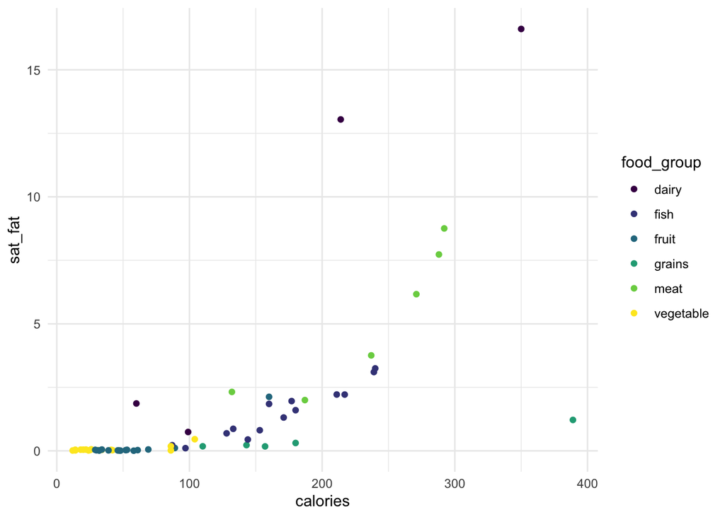

```r
food %>%
  ggplot() +
    geom_point(aes(x = calories, y = sat_fat, color = food_group)) +
    scale_color_viridis_d()
```

There is also `scale_color_viridis_c` that produces a similar set of colors when you want to color point according to a continuous variable.

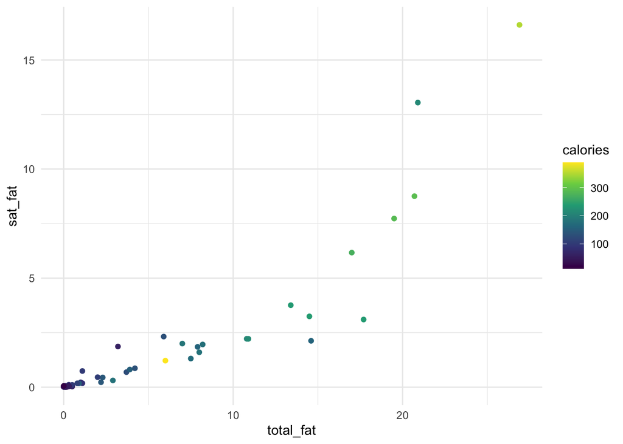

```r
food %>%
  ggplot() +
    geom_point(aes(x = total_fat, y = sat_fat, color = calories)) +
    scale_color_viridis_c()
```

Similarly, there are several scales to control the x and y axes. For example, we can add `scale_x_log10()` and `scale_y_log10()` to the plot to produce a plot on a logarithmic scale, which can be very useful when working with heavily skewed datasets:

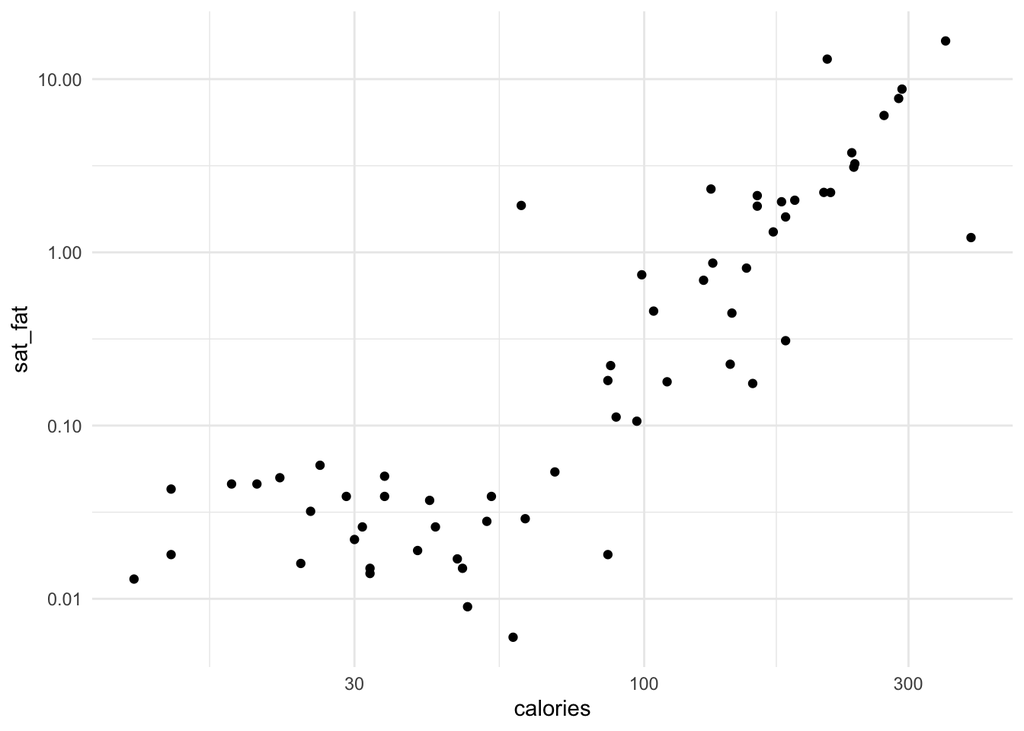

```r
food %>%
  ggplot() +
    geom_point(aes(x = calories, y = sat_fat)) +
    scale_x_log10() +
    scale_y_log10()
```

The functions `scale_x_continuous()` and `scale_y_continuous()` reproduce the default axes, but are useful for setting other details such as where to draw horizontal and vertical guidelines.

## Extra color scales

There are several special scale types that can be useful for working with colors. In some cases we may already have a column in our dataset that explicitly describes the color of an observations. This is, in fact, the case with the food dataset. In this case, we may want to use these colors directly. To do that, use the scale `scale_color_identity`. Here is an example with each food colored according to its assigned color:

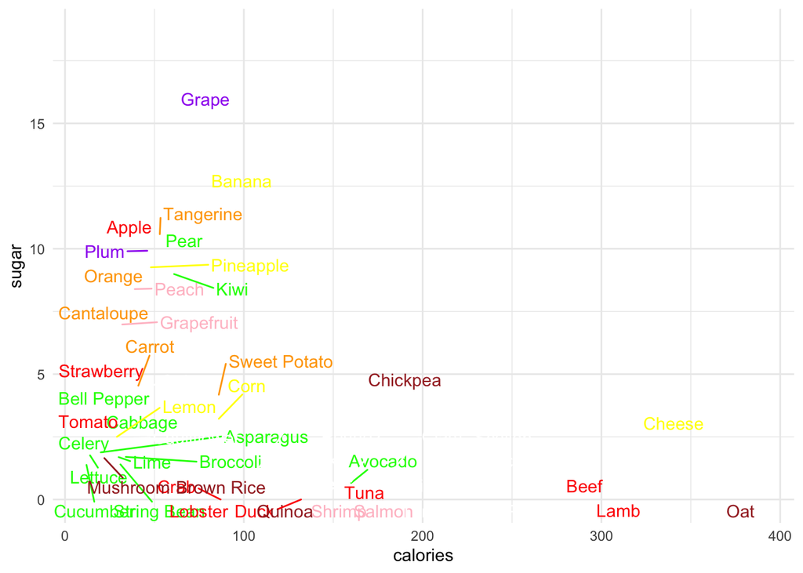

```r
food %>%
  ggplot() +
    geom_text_repel(
      aes(x = calories, y = sugar, color = color, label = item)
    ) +
    scale_color_identity()
```

Notice that by default no legend is created for the scale.

Another type of scale that can be useful for colors is `scale_color_manual`. Here, it is possible to describe exactly which color should be used for each category. Here is the syntax, with manually defined colors for each food group:

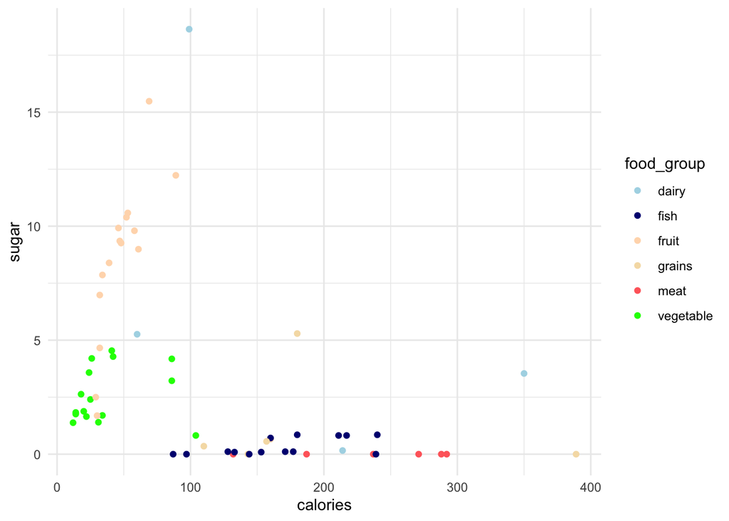

```r
food %>%
  ggplot() +
    geom_point(aes(x = calories, y = sugar, color = food_group)) +
    scale_color_manual(values = c(
      dairy = "lightblue",
      fish = "navy",
      fruit = "peachpuff1",
      grains = "wheat",
      meat = "indianred1",
      vegetable = "green"
    ))
```

Using manual colors is generally advisable in the case where there are well-known colors associated with the groups in the dataset. For example, when plotting data about political parties it may make be helpful to use the colors traditionally associated with each party.

## Inheritance of aesthetics

As a final optional point, note that there is a convention for simplifying the plotting command. Often, each layer will use the same x and y variables. It is possible to specify these just once in the `ggplot` function, and they will be used by default in all other layers. Also, you can drop the `x =` and `y =` if you put these options first. Here is an example of layering together the `geom_point` and `geom_text_repel` with this inheritance structure:

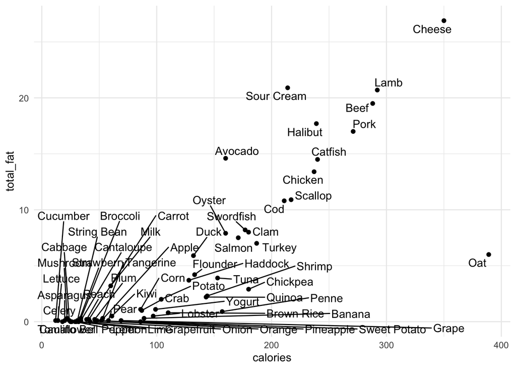

```r
food %>%
  ggplot(aes(calories, total_fat)) +
    geom_point() +
    geom_text_repel(aes(label = item))
```

These changes are optional however, and you can feel free to write them as we did earlier if you prefer. It is important to be able to recognize them, though, if you are searching through documentation or help pages.

## Exercises and References

There is are exercise notebook for this chapter:

- **exercies03A.Rmd**: practice producing graphics for a new dataset
- **exercies03B.Rmd**: open-ended questions to explore with data

It is strongly recommended to complete at least the first notebook prior to continuing on to the next chapter.

Here are several good resources if you want to learn more about the Grammar of Graphics in R:

- [R for Data Science: Chapter 3](http://r4ds.had.co.nz/data-visualisation.html)
- [ggplot2 cheatsheet](https://www.rstudio.com/wp-content/uploads/2015/03/ggplot2-cheatsheet.pdf)
- [ggplot2 aesthetic vignette](https://cran.r-project.org/web/packages/ggplot2/vignettes/ggplot2-specs.html)

If you search online for help with R graphics, make sure to add the term “ggplot” to your query as otherwise you may find advice for using other graphics engines in R that will not be applicable to the approach presented here.